# Maximisation d’une fonction linéaire

Felix Martins, Nolan Correard, Arthus Nemoz-Gaillard, Fabio Brambilla, Louis Vicat, Loris Vullion

17/05/2024

# Introduction

Dans le cadre de notre organisation de tournoi, nous cherchons à vendre du merch (produits dérivés) pendant les évènements physiques. Nous décidons dans ce cadre de vendre deux types de merch, des tshirt et des magnets, et posons les prix de ceux-ci à 5 euros pour un magnet et 12 euros pour un tshirt. Nous cherchons à maximiser l’argent récolté dans le cas où chacunes des unités préparées est vendue. Dans ce cadre, nous posons la fonction $f(x, y) = 5x + 12y$ qui représente l’argent récolté et où $x$ représente le nombre de magnets vendus et $y$ le nombre de tshirts vendus. La question de la maximisation de l’argent récolté devient alors celle de la maximisation de la fonction $f$.

# Contraintes

Nous posons cependant certaines contraintes qui limitent notre champs d’action :

- Le nombre d’unités de chaque type doit être positif.
- En raison de la taille du camion, le nombre total d’unités doit être inférieur à 50.
- En raison du poids maximal transportable par nos équipements, le poids total des unités doit être inférieur à 15kg, sachant que chaque magnet pèse 100g et que chaque tshirt pèse 500g.

Nous formalisons les contraintes précédentes comme suit :
$$\begin{cases}
x,y\geq 0\\
x + y \leq 50 \\
0.1x + 0.5y \leq 15
\end{cases}$$

# Résolution graphique

Afin de résoudre graphiquement le maximum de $f$ qui réspecte les contraintes énnoncées précédemment, on représente le domaine des contraintes dans le plan :

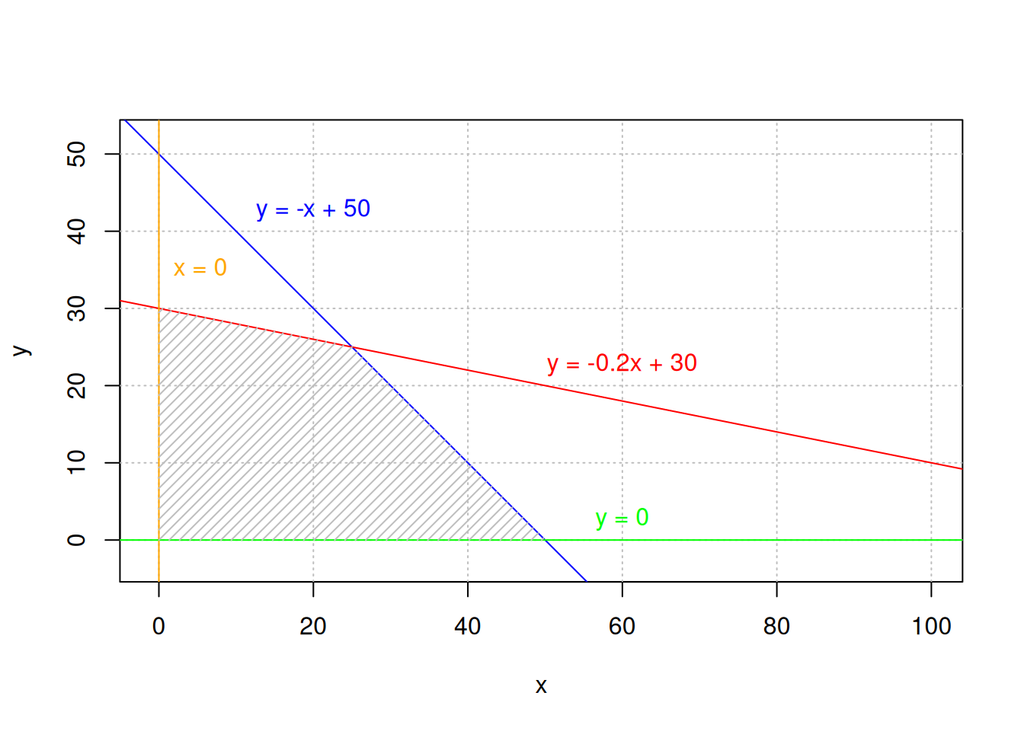

Nous avons ici représenté les contraintes énnoncées plus haut. Avec ces représentations graphiques, nous pouvons visuellement voir nos contraintes; nous avons hachuré en gris le domaine des contraintes, c’est-à-dire la zone telle que les points $(x, y)$ réspectent toutes les contraintes précédemment énnoncées. Ainsi, nous pouvons représenter graphiquement la fonction, qu’on déplace afin de trouver les valeurs de $x$ et $y$ qui la maximisent.

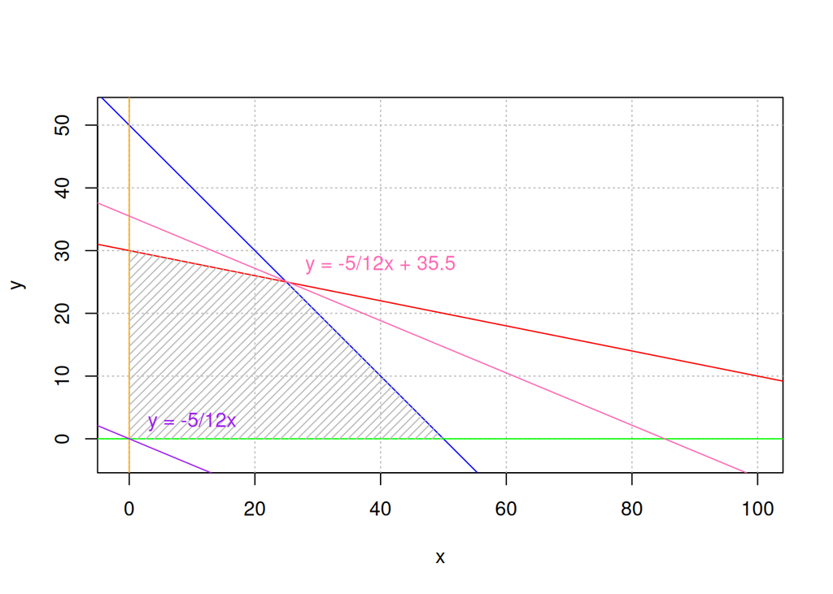

Nous avons ici représenté la fonction qu’on cherche à maximiser en violet et une fonction qui en découle en rose, modifié afin qu’un point de celle-ci soit le maximum qui correspond à nos contraintes. Ainsi, nous pouvons déduire graphiquement que les valeurs de $x$ et $y$ qui maximisent la fonction $f(x, y) = 5x + 12y$ tout en respectant nos contraintes sont $x = 25$ et $y = 25$.

# Résolution par simplex

Nous cherchons désoirmais à résoudre le problème de maximisation de $f$ en utilisant la méthode du simplex. Nous utilisons pour cela la fonction simplex du package boot de R :

```r
z = c(5, 12)
A1 = matrix(c(1, 0.1, 1, 0.5), 2, 2)
b1 = c(50, 15)
result = simplex(
  a = z,
  A1 = A1,
  b1 = b1,
  maxi = TRUE
)
result
```

```
##
## Linear Programming Results
##
## Call : simplex(a = z, A1 = A1, b1 = b1, maxi = TRUE)
##
## Maximization Problem with Objective Function Coefficients
## x1 x2
##  5 12
##
##
## Optimal solution has the following values
## x1 x2
## 25 25
## The optimal value of the objective  function is 425.
```

Le code ci-dessus définit les vécteurs et matrices correspondantes à nos contraintes et appelle la fonction simplex pour résoudre le problème de maximisation de $f$. On voit alors que le résultat trouvé avec cette méthode est le même que celui trouvé graphiquement, à savoir $x = 25$ et $y = 25$.

# Conclusion